# Cognitive biases in ecosystem service provider networks may obstruct the ecological intensification of agriculture

Supplementary Material

2026-06-07

Gábor Pozsgai<sup>1,2,3*§</sup>, Kris A.G. Wyckhuys<sup>1,2,4,5,6§</sup>, Ibtissem Ben Fekih<sup>1,7,8§</sup>, Liette Vasseur<sup>1,2,9</sup>, Geoff Gurr<sup>1,2,10</sup>, Mark Goettel<sup>1,2,11</sup>, Heather VanVolkenburg<sup>9</sup>, Sunita Pandey<sup>12</sup>, Jamile Queiroz-Sousa<sup>13</sup>, Pingyang Zhu<sup>14</sup>, Mohammed Abul Monjur Khan<sup>15</sup>, Titus Imboma<sup>1,2,16</sup>, Margaret Hughes<sup>17,18</sup>, Jian Liu1<sup>9</sup>, Syed Rizvi<sup>20</sup>, Olivia Reynolds<sup>1,2,10</sup>, Hafiz Sohaib Ahmed Saqib<sup>1,2,21</sup>, Stephen Wratten<sup>1,2,22†</sup>, Jie Zhang<sup>1,2,23</sup>, Wenwu Zhou<sup>24</sup>, Francisco Javier Garcia<sup>25</sup>, Lucas Alexander Shuttleworth<sup>26</sup>, Li-Lin Chen<sup>1,2</sup>, Gábor L. Lövei<sup>1,2,13*</sup>, Minsheng You<sup>1,2*</sup>

<sup>1</sup>State Key Laboratory of Agriculture and Forestry Biosecurity, Institute of Applied Ecology, Fujian Agriculture and Forestry University, Fuzhou 350002, China

<sup>2</sup>Joint International Research Laboratory of Ecological Pest Control, Ministry of Education, Fuzhou 350002, China

<sup>3</sup>University of the Azores, Angra do Heroismo, Portugal

<sup>4</sup>Chrysalis Consulting, Danang, Vietnam

<sup>5</sup>School of the Environment, The University of Queensland, Saint Lucia, Australia

<sup>6</sup>Institute of Plant Protection, Chinese Academy of Agricultural Sciences (CAAS), Beijing, China

<sup>7</sup>Institute of Environmental Microbiology, College of Resources and Environment, Fujian Agriculture and Forestry University, Fuzhou, China

<sup>8</sup>Functional and Evolutionary Entomology, Terra, Gembloux Agro-Bio Tech, University of Liege, Passage des Déportés 2, 5030 Gembloux, Belgium.

<sup>9</sup>UNESCO Chair on Community Sustainability: From Local to Global, Dept. Biol. Sci., Brock University, Canada

<sup>10</sup>Gulbali Institute, School of Agriculture, Environment and Veterinary Sciences, Charles Sturt University, Orange NSW 2800, Australia

<sup>11</sup>Agriculture and Agri-Food Canada, Lethbridge Research Centre, Lethbridge, AB, Canada

<sup>12</sup>Ministry of Agriculture and Livestock Development, Singhadurbar, Nepal

<sup>13</sup>Jamile Queiroz-Sousa

<sup>14</sup>College of Life Sciences, Zhejiang Normal University, Jinhua 321004, China

<sup>15</sup>Department of Entomology, Faculty of Agriculture, Bangladesh Agricultural University, Mymensingh-2202, Bangladesh

<sup>16</sup>Ornithology Section of the Zoology Department, National Museums of Kenya, PO Box 40658- 00100, GPO. Nairobi, Kenya <sup>17</sup>Department of Biological Sciences, University of Calgary, Calgary, AB, Canada

<sup>18</sup>Department of Biological Sciences, Brock University, St. Catharines, ON, Canada

<sup>19</sup>Artificial Intelligence and Cyber Futures Centre, Charles Sturt University, Orange NSW 2800, Australia

<sup>20</sup>Applied Biosciences, Macquarie University, Sydney, Australia

<sup>21</sup>Yunnan Key Laboratory of Forest Ecosystem Stability and Global Change, Xishuangbanna Tropical Botanical Garden, Chinese Academy of Sciences, Menglun, Mengla, Yunnan 666303, China

<sup>22</sup>Bio-Protection Research Centre, Lincoln University, New Zealand

<sup>23</sup>Fujian Key Laboratory for Monitoring and Integrated Management of Crop Pests, Fujian Engineering Research Center for Green Pest Management, Institute of Plant Protection, Fujian Academy of Agricultural Sciences, Fuzhou 350013, China

<sup>24</sup>State Key Laboratory of Rice Biology, Key Laboratory of Molecular Biology of Crop Pathogens and Insects, Ministry of Agriculture, Zhejiang University, Hangzhou, China

<sup>25</sup>Independent researcher, Spain

<sup>26</sup>National Institute of Agricultural Botany (NIAB), Department of Pest & Pathogen Ecology, East Malling, Kent ME19 6BJ United Kingdom

<sup>13</sup>Department of Agroecology, Flakkebjerg Research Centre, Aarhus University, 4200 Slagelse, Denmark

<sup>§</sup>These authors contributed equally to this work.

†Deceased; contributed to this work prior to passing

*Corresponding authors: msyou@fafu.edu.cn, gabor.lovei@agro.au.dk, pozsgaig@coleoptera.hu

## Hypothetical network input

Table 1: Contents of the hypothetical network input workbook (prednet.xlsx).

| ESP_name | ESP | ES_ESD_name | Type | Keyword | Rationale/Example | Comments |
| --- | --- | --- | --- | --- | --- | --- |
| Earthworms | Annelida | Damage on crop | EDS | Crop damage | Earthworms can mechanically damage crop roots | NA |
| Birds | Bird* | Damage on crop | EDS | Crop damage | Birds eat crop seeds | NA |
| Beetles | Coleoptera | Damage on crop | EDS | Crop damage | Herbivorous beetles feeding on crop species. | NA |
| Springtails | Collembola | Damage on crop | EDS | Crop damage | Garden springtail (Bourltiella hortensis) can feed on crop leaves. | NA |
| Flies and mosquitos | Diptera | Damage on crop | EDS | Crop damage | Cabbage fly eating Brassicaceae species. | NA |
| Fungi | Fung* | Damage on crop | EDS | Crop damage | Claviceps species infecting wheat. | NA |
| Bugs and aphids etc. | Hemiptera | Damage on crop | EDS | Crop damage | Aphids sucking on crop. | NA |
| Butterflies and moths | Lepidoptera | Damage on crop | EDS | Crop damage | Caterpillars chewing on crop. | NA |
| Mammals | Mammal* | Damage on crop | EDS | Crop damage | Voles eating crop seeds. | NA |
| Mites | Mite* | Damage on crop | EDS | Crop damage | Mites causing direct damage on crop | NA |
| Molluscs | Mollusc* | Damage on crop | EDS | Crop damage | Slugs eating crop leaves | NA |
| Nematods | Nematod* | Damage on crop | EDS | Crop damage | Nematode damage on potatoes. | NA |
| Viruses | Virus* | Damage on crop | EDS | Crop damage | Virus infections on tobacco | NA |
| Wild plants | Wild plant* | Damage on crop | EDS | Crop damage | Competition with crops | NA |
| Bugs and aphids etc. | Hemiptera | Spreading diseases | EDS | Disease vector | May be viros vectors for crops | NA |
| Wasps, bees and ants | Hymenoptera | Ecosystem engineering | EDS | Ecosystem engineering | Ants move soil | NA |
| Mammals | Mammal* | Ecosystem engineering | EDS | Ecosystem engineering | Moles dig holes | NA |
| Amphibians | Amphibian* | Human fears | EDS | Fear* | Frogs may induce disgust in humans. | NA |
| Mammals | Mammal* | Human fears | EDS | Fear* | Fear of mice or large mammals | NA |
| Reptiles | Reptile* | Human fears | EDS | Fear* | Disgust of snakes. | NA |
| Bacteria | Bacteria | Human health issues | EDS | Human health | Bacteria causing diseases. | NA |
| Flies and mosquitos | Diptera | Human health issues | EDS | Human health | Tabanidae species spread human disaeses from livestock | NA |
| Fungi | Fung* | Human health issues | EDS | Human health | Claviceps species are poisonous to humans. | NA |
| Mammals | Mammal* | Human health issues | EDS | Human health | Badgers spreading bovine TBC. | NA |
| Wild plants | Wild plant* | Human health issues | EDS | Human health | Hayfiever | NA |
| Birds | Bird* | Facilitation of pest dispersal | EDS | Pest dispersal | Foretic pests | NA |
| Mammals | Mammal* | Facilitation of pest dispersal | EDS | Pest dispersal | Foretic pests | NA |
| Wild plants | Wild plant* | Habitat and food for pests | EDS | Pest refuge | Wild plants provide refuge for pests | NA |
| Amphibians | Amphibian* | Negative impact on beneficial organisms | EDS | Reduc* benefit* | Frogs may predate on parasites or predators of pests. | NA |
| Birds | Bird* | Negative impact on beneficial organisms | EDS | Reduc* benefit* | Birds predating on parasites or predators of pests. | NA |

[output cut: 74 more lines]

## AI Model Performance (LLMs)

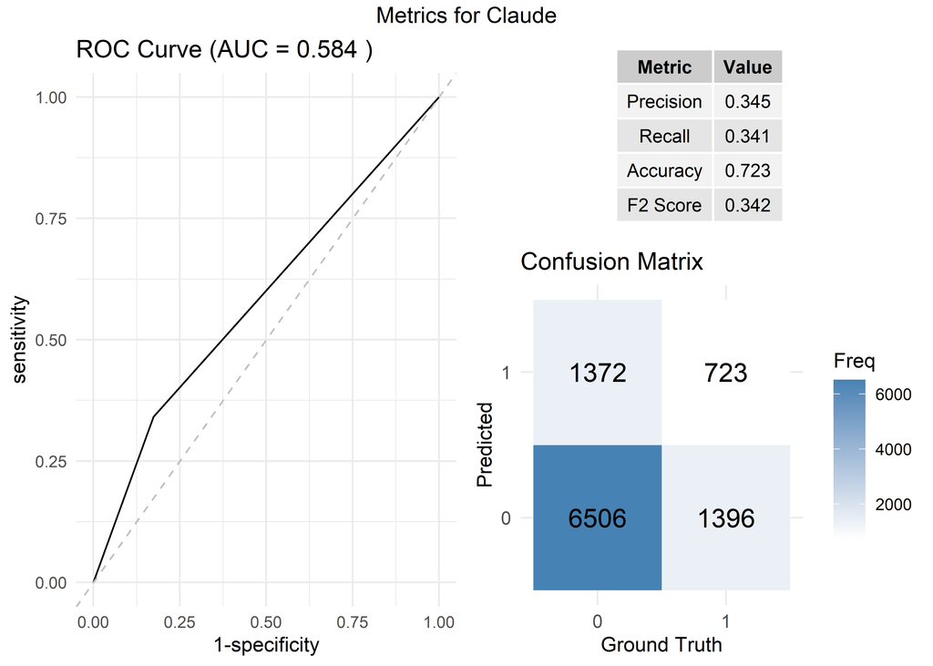

Figure 1: Metrics for AI: Claude

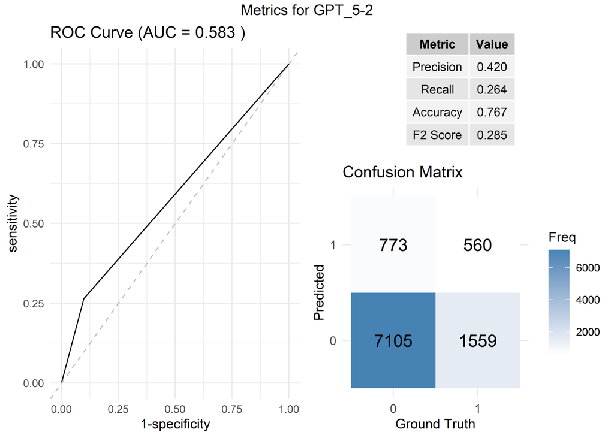

Figure 2: Metrics for AI: GPT_5-2

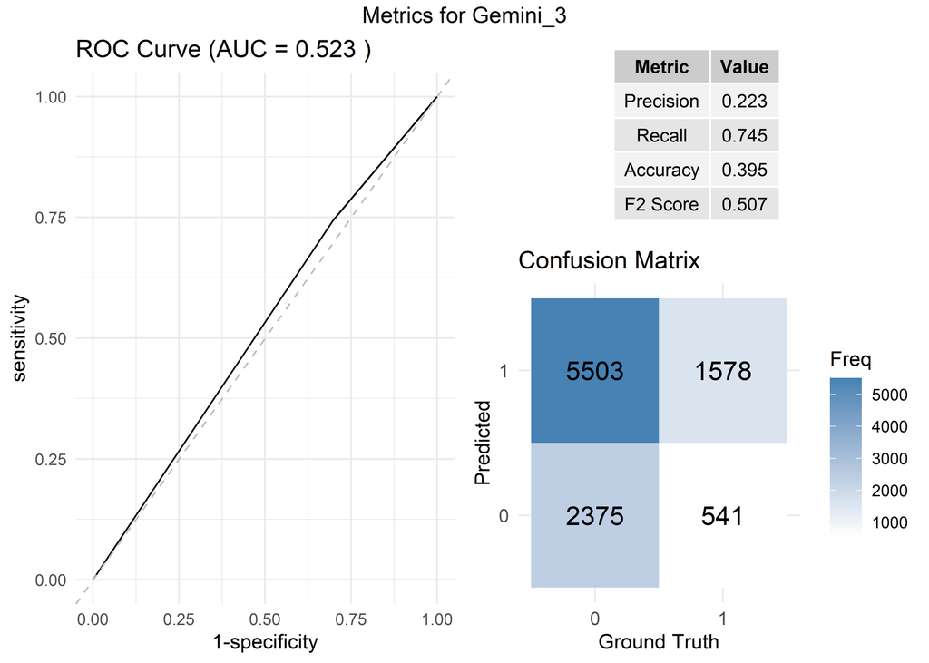

Figure 3: Metrics for AI: Gemini_3

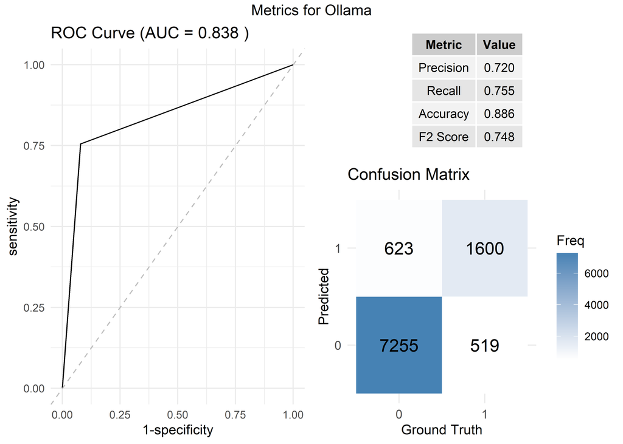

Figure 4: Metrics for AI: Ollama

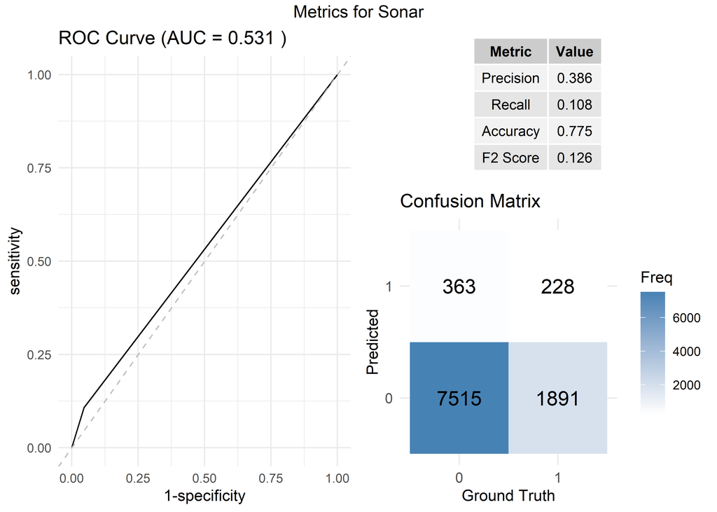

Figure 5: Metrics for AI: Sonar

## ML Model Performance Comparison (Non-LLMs)

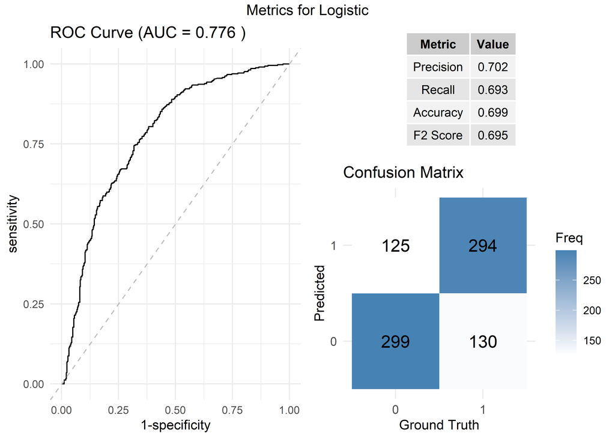

Figure 6: Metrics for Logistic

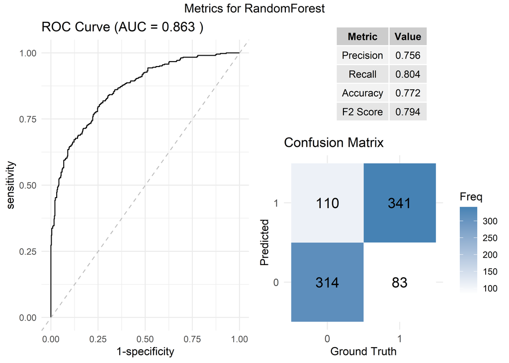

Figure 7: Metrics for RandomForest

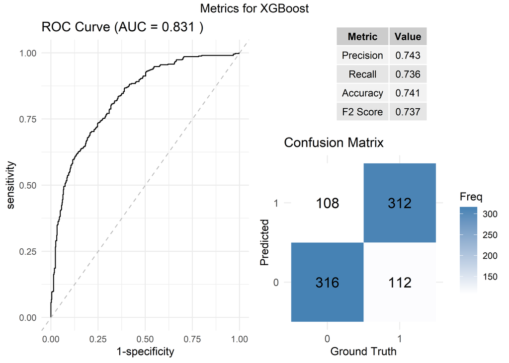

Figure 8: Metrics for XGBoost

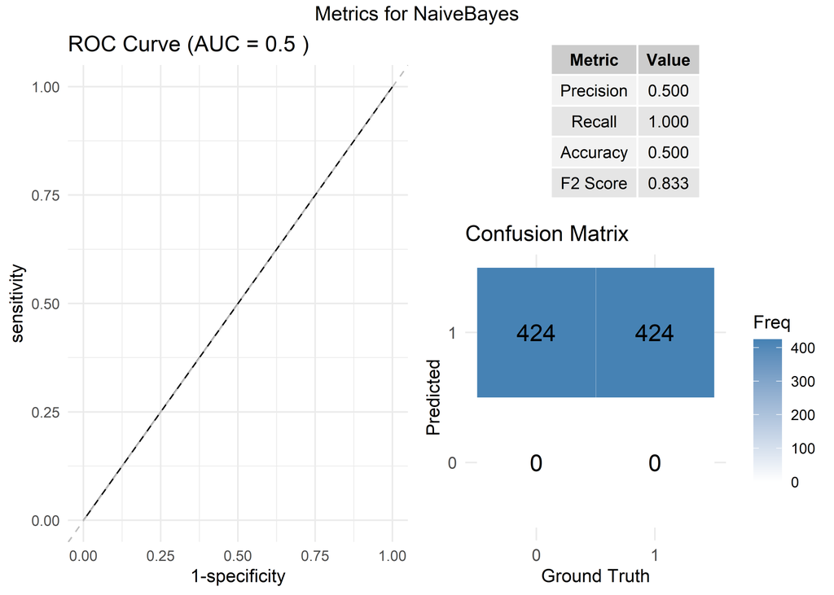

Figure 9: Metrics for NaiveBayes

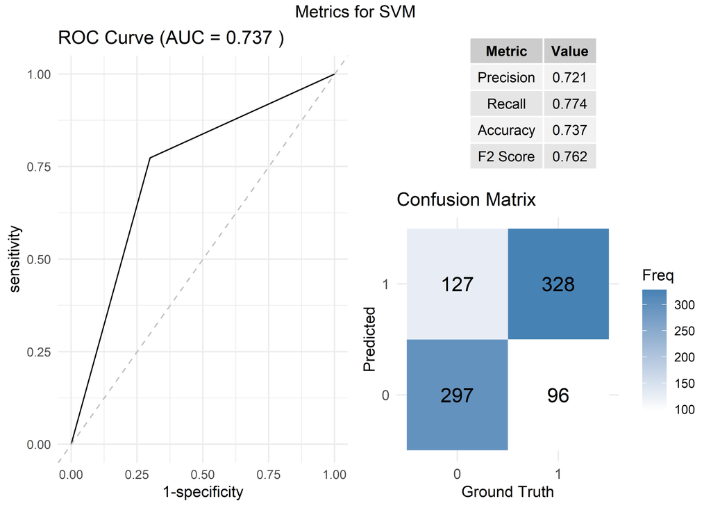

Figure 10: Metrics for SVM

## Node degree loss

Table 2: ES nodes: degree in predicted and realised networks and total realised papers per node.

| Node | Abbr. | Pred. degree | Real. degree | Real. total papers |
| --- | --- | --- | --- | --- |
| Aesthetics | Asthtc | 4 | 1 | 1 |
| Biopesticide | Bpstcd | 1 | 0 | 0 |
| Climate and weather regulation | Clmawr | 1 | 0 | 0 |
| Cultural practices | Cltrlp | 3 | 0 | 0 |
| Decomposition | Dcmpst | 6 | 5 | 130 |
| Detoxification | Dtxfct | 2 | 1 | 8 |
| Fibre | Fibre | 1 | 0 | 0 |
| Food provision | Fdprvs | 6 | 5 | 200 |
| Fuel | Fuel | 1 | 0 | 0 |
| Pest control | Pstcnt | 14 | 14 | 410 |
| Pharmaceutical | Phrmct | 1 | 0 | 0 |
| Pigment | Pigmnt | 2 | 1 | 1 |
| Pollination | Pllntn | 4 | 4 | 154 |
| Recreation | Recrtn | 3 | 0 | 0 |
| Seed dispersal | Sddspr | 3 | 3 | 10 |
| Soil functions | Slfnct | 4 | 3 | 74 |
| Timber | Timber | 1 | 0 | 0 |
| Weed control | Wdcntr | 4 | 4 | 15 |

Table 3: EDS nodes: degree in predicted and realised networks and total realised papers per node.

| Node | Abbr. | Pred. degree | Real. degree | Real. total papers |
| --- | --- | --- | --- | --- |
| Damage on crop | Dmgonc | 14 | 12 | 106 |
| Ecosystem engineering | Ecsyse | 2 | 0 | 0 |
| Faciliation of the spread of the weeds | Fotsotw | 3 | 0 | 0 |
| Facilitation of pest dispersal | Fclopd | 2 | 0 | 0 |
| Habitat and food for pests | Hbaffp | 1 | 0 | 0 |
| Human fears | Hmnfrs | 3 | 1 | 1 |
| Human health issues | Hmnhli | 5 | 3 | 40 |
| Negative impact on beneficial organisms | Ngiobo | 11 | 0 | 0 |
| Spreading diseases | Sprdnd | 1 | 1 | 4 |

Table 4: ESP nodes: degrees and realised evidence (ES/EDS links and paper weights in brackets).

| Node | Abbr. | Pred. degree (ES; EDS) | Real. degree (ES; EDS) | Real. papers (ES; EDS) |
| --- | --- | --- | --- | --- |
| Amphibians | Amphbn | 3 (ES 1; EDS 2) | 1 (ES 1; EDS 0) | 2 (ES 2; EDS 0) |
| Bacteria | Bacter | 4 (ES 3; EDS 1) | 4 (ES 3; EDS 1) | 106 (ES 83; EDS 23) |
| Beetles | Beetls | 9 (ES 6; EDS 3) | 7 (ES 6; EDS 1) | 102 (ES 88; EDS 14) |
| Birds | Birds | 11 (ES 7; EDS 4) | 5 (ES 4; EDS 1) | 95 (ES 78; EDS 17) |
| Bugs and aphids etc. | Baaet. | 5 (ES 2; EDS 3) | 4 (ES 2; EDS 2) | 75 (ES 60; EDS 15) |
| Butterflies and moths | Bttram | 4 (ES 3; EDS 1) | 4 (ES 3; EDS 1) | 68 (ES 46; EDS 22) |
| Earthworms | Erthwr | 3 (ES 2; EDS 1) | 0 (ES 0; EDS 0) | 0 (ES 0; EDS 0) |
| Flies and mosquitos | Flsanm | 3 (ES 1; EDS 2) | 3 (ES 1; EDS 2) | 46 (ES 40; EDS 6) |
| Fungi | Fungi | 7 (ES 4; EDS 3) | 6 (ES 4; EDS 2) | 310 (ES 285; EDS 25) |
| Mammals | Mammls | 14 (ES 7; EDS 7) | 6 (ES 4; EDS 2) | 28 (ES 20; EDS 8) |
| Microsporidia | Mcrspr | 2 (ES 1; EDS 1) | 1 (ES 1; EDS 0) | 1 (ES 1; EDS 0) |
| Mites | Mites | 3 (ES 1; EDS 2) | 2 (ES 1; EDS 1) | 41 (ES 39; EDS 2) |
| Molluscs | Mllscs | 2 (ES 1; EDS 1) | 1 (ES 0; EDS 1) | 2 (ES 0; EDS 2) |
| Nematods | Nemtds | 3 (ES 2; EDS 1) | 3 (ES 2; EDS 1) | 53 (ES 40; EDS 13) |
| Reptiles | Reptls | 3 (ES 1; EDS 2) | 1 (ES 1; EDS 0) | 1 (ES 1; EDS 0) |
| Spiders | Spidrs | 2 (ES 1; EDS 1) | 1 (ES 1; EDS 0) | 99 (ES 99; EDS 0) |
| Springtails | Sprngt | 4 (ES 3; EDS 1) | 4 (ES 3; EDS 1) | 8 (ES 7; EDS 1) |
| Viruses | Viruss | 1 (ES 0; EDS 1) | 1 (ES 0; EDS 1) | 3 (ES 0; EDS 3) |
| Wasps, bees and ants | Ws,baa | 4 (ES 2; EDS 2) | 2 (ES 2; EDS 0) | 104 (ES 104; EDS 0) |
| Wild plants | Wldpln | 16 (ES 13; EDS 3) | 2 (ES 2; EDS 0) | 10 (ES 10; EDS 0) |

[figure not shown]

## Network projections

Table 5: ES/EDS bundle structure in predicted and realised networks. For each ecosystem service (ES) or disservice (EDS), the number of ES and EDS neighbours in the projection network (bundled through shared ESPs) and the total number of ESPs mediating those bundles are shown separately for predicted and realised networks.

| ES/EDS | Type | Predicted Links (ES) | Predicted Links (EDS) | Predicted ESPs (ES) | Predicted ESPs (EDS) | Realised Links (ES) | Realised Links (EDS) | Realised ESPs (ES) | Realised ESPs (EDS) |
| --- | --- | --- | --- | --- | --- | --- | --- | --- | --- |
| Damage on crop | EDS | 18 | 8 | 52 | 19 | 9 | 3 | 30 | 4 |
| Ecosystem engineering | EDS | 8 | 6 | 9 | 7 | 0 | 0 | 0 | 0 |
| Faciliation of the spread of the weeds | EDS | 10 | 6 | 20 | 11 | 0 | 0 | 0 | 0 |
| Facilitation of pest dispersal | EDS | 7 | 6 | 14 | 9 | 0 | 0 | 0 | 0 |
| Habitat and food for pests | EDS | 13 | 2 | 13 | 2 | 0 | 0 | 0 | 0 |
| Human fears | EDS | 7 | 6 | 9 | 8 | 4 | 1 | 4 | 1 |
| Human health issues | EDS | 18 | 7 | 28 | 11 | 6 | 1 | 8 | 2 |
| Negative impact on beneficial organisms | EDS | 11 | 7 | 33 | 19 | 0 | 0 | 0 | 0 |
| Spreading diseases | EDS | 2 | 2 | 2 | 2 | 2 | 1 | 2 | 1 |
| Aesthetics | ES | 15 | 8 | 26 | 15 | 2 | 1 | 2 | 1 |
| Biopesticide | ES | 12 | 3 | 12 | 3 | 0 | 0 | 0 | 0 |
| Climate and weather regulation | ES | 12 | 3 | 12 | 3 | 0 | 0 | 0 | 0 |
| Cultural practices | ES | 14 | 8 | 24 | 14 | 0 | 0 | 0 | 0 |
| Decomposition | ES | 8 | 4 | 14 | 10 | 8 | 2 | 13 | 6 |
| Detoxification | ES | 14 | 3 | 14 | 4 | 2 | 1 | 2 | 1 |
| Fibre | ES | 12 | 3 | 12 | 3 | 0 | 0 | 0 | 0 |
| Food provision | ES | 17 | 8 | 29 | 19 | 7 | 3 | 12 | 6 |
| Fuel | ES | 12 | 3 | 12 | 3 | 0 | 0 | 0 | 0 |
| Pest control | ES | 17 | 9 | 37 | 35 | 7 | 4 | 20 | 11 |
| Pharmaceutical | ES | 12 | 3 | 12 | 3 | 0 | 0 | 0 | 0 |
| Pigment | ES | 16 | 5 | 17 | 6 | 5 | 1 | 5 | 1 |
| Pollination | ES | 7 | 5 | 8 | 8 | 7 | 2 | 8 | 4 |
| Recreation | ES | 14 | 8 | 24 | 14 | 0 | 0 | 0 | 0 |
| Seed dispersal | ES | 9 | 7 | 17 | 14 | 6 | 2 | 11 | 4 |
| Soil functions | ES | 4 | 3 | 8 | 6 | 4 | 2 | 7 | 4 |
| Timber | ES | 12 | 3 | 12 | 3 | 0 | 0 | 0 | 0 |
| Weed control | ES | 9 | 8 | 18 | 17 | 6 | 3 | 12 | 6 |

Table 6: ESP projection structure in predicted and realised networks. For each ecosystem service provider (ESP), the degree in the ESP projection network (number of other ESPs linked through shared services/disservices) and the number of ES and EDS that are shared with at least one other ESP are shown separately for predicted and realised networks.

| ESP | Predicted Linked ESPs | Predicted Shared ES | Predicted Shared EDS | Realised Linked ESPs | Realised Shared ES | Realised Shared EDS |
| --- | --- | --- | --- | --- | --- | --- |
| Amphibians | 13 | 2 | 1 | 13 | 1 | 0 |
| Bacteria | 8 | 1 | 3 | 5 | 2 | 1 |
| Beetles | 19 | 3 | 6 | 18 | 5 | 1 |
| Birds | 18 | 4 | 7 | 17 | 4 | 1 |
| Bugs and aphids etc. | 18 | 2 | 2 | 17 | 2 | 1 |
| Butterflies and moths | 14 | 1 | 3 | 13 | 2 | 1 |
| Earthworms | 14 | 1 | 2 | 0 | 0 | 0 |
| Flies and mosquitos | 15 | 2 | 1 | 13 | 1 | 2 |
| Fungi | 19 | 3 | 4 | 18 | 4 | 2 |
| Mammals | 19 | 7 | 7 | 17 | 4 | 1 |
| Microsporidia | 13 | 1 | 1 | 13 | 1 | 0 |
| Mites | 18 | 2 | 1 | 17 | 1 | 1 |
| Molluscs | 13 | 1 | 1 | 11 | 0 | 1 |
| Nematods | 19 | 1 | 2 | 18 | 2 | 1 |
| Reptiles | 13 | 2 | 1 | 13 | 1 | 0 |
| Spiders | 13 | 1 | 1 | 13 | 1 | 0 |
| Springtails | 19 | 1 | 3 | 18 | 3 | 1 |
| Viruses | 13 | 1 | 0 | 11 | 0 | 1 |
| Wasps, bees and ants | 15 | 2 | 2 | 15 | 2 | 0 |
| Wild plants | 19 | 2 | 7 | 14 | 2 | 0 |

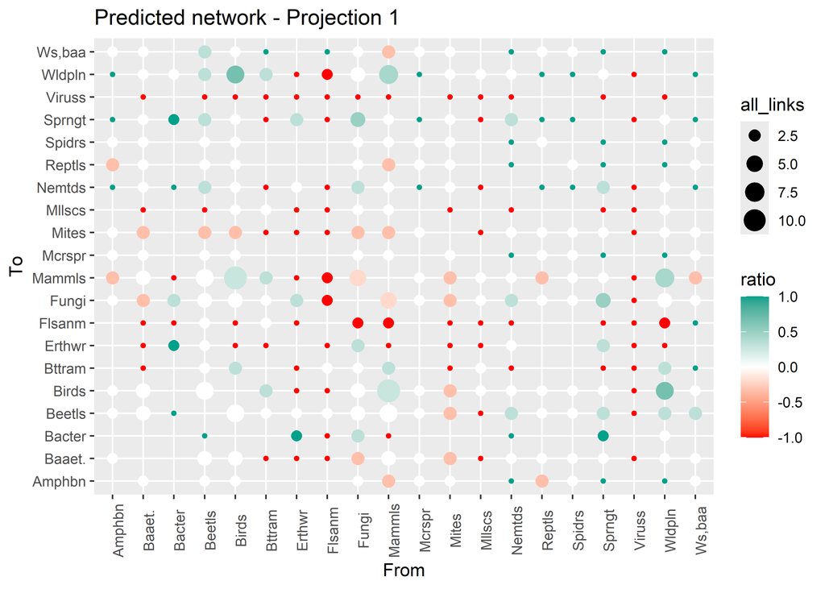

Figure 12: Predicted network - Projection 1

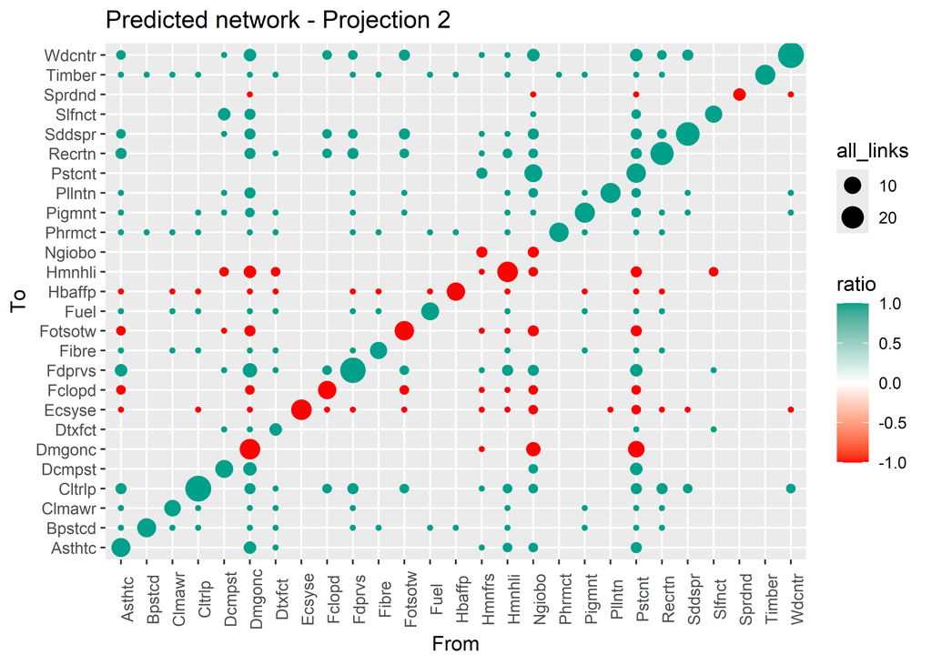

Figure 13: Predicted network - Projection 2

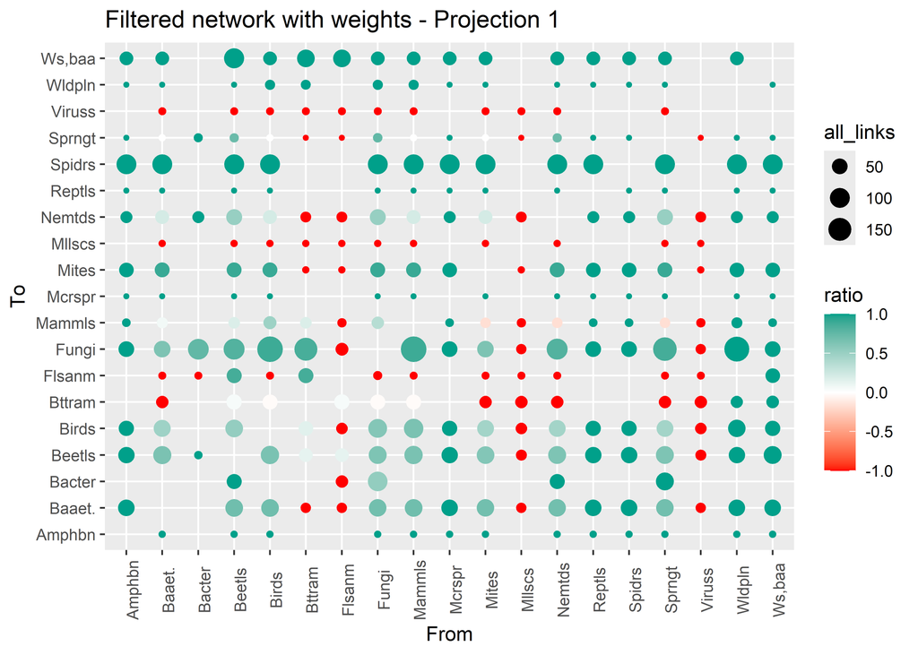

Figure 14: Filtered network with weights - Projection 1

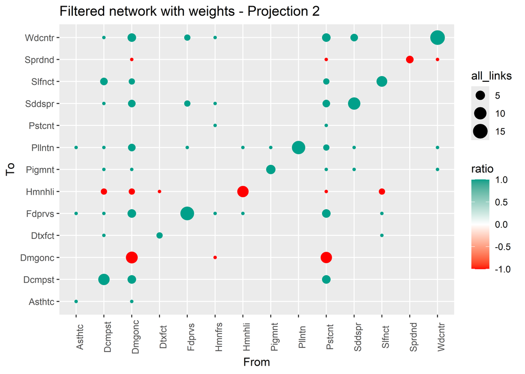

Figure 15: Filtered network with weights - Projection 2

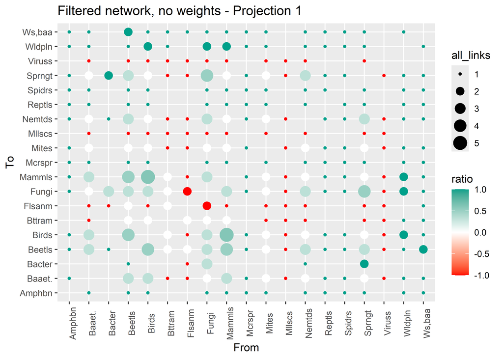

Figure 16: Filtered network, no weights - Projection 1

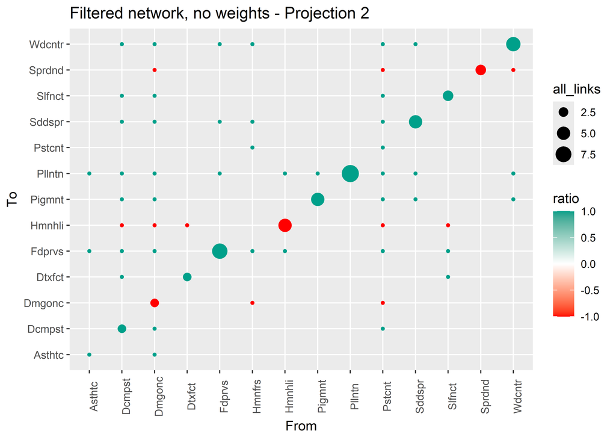

Figure 17: Filtered network, no weights - Projection 2